# Statistical Rethinking (Code)

#### R Code 12.41

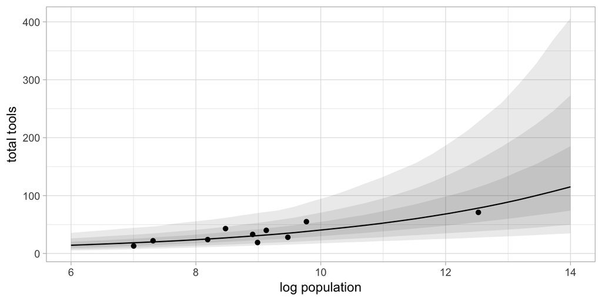

```r
m12.6_pred <-
  m12.6_pred %>%
  mutate(
    mu.median = apply(m12.6_link, 2, median),
    link67.lo = apply(m12.6_link, 2, PI, prob = 0.67)[1,],
    link67.hi = apply(m12.6_link, 2, PI, prob = 0.67)[2,],
    link89.lo = apply(m12.6_link, 2, PI, prob = 0.89)[1,],
    link89.hi = apply(m12.6_link, 2, PI, prob = 0.89)[2,],
    link97.lo = apply(m12.6_link, 2, PI, prob = 0.97)[1,],
    link97.hi = apply(m12.6_link, 2, PI, prob = 0.97)[2,]
  )

gf_ribbon(link67.lo + link67.hi ~ logpop, data = m12.6_pred, alpha = 0.1) %>%
gf_ribbon(link89.lo + link89.hi ~ logpop, data = m12.6_pred, alpha = 0.1) %>%
gf_ribbon(link97.lo + link97.hi ~ logpop, data = m12.6_pred, alpha = 0.1) %>%
gf_point(total_tools ~ logpop, data = Kline) %>%
  gf_labs(x = "log population", y = "total tools") %>%
  gf_line(mu.median ~ logpop, data = m12.6_pred)
```

#### R Code 12.42

There is one missing district number

```r
data(bangladesh)
# would you have noticed that 54 is missing in this list?
sort(unique(bangladesh$district))
```

```
##  [1]  1  2  3  4  5  6  7  8  9 10 11 12 13 14 15 16 17 18 19 20 21 22 23
## [24] 24 25 26 27 28 29 30 31 32 33 34 35 36 37 38 39 40 41 42 43 44 45 46
## [47] 47 48 49 50 51 52 53 55 56 57 58 59 60 61
```

```r
# it is easier to spot the 2 in this list
diff(sort(unique(bangladesh$district)))
```

```
##  [1] 1 1 1 1 1 1 1 1 1 1 1 1 1 1 1 1 1 1 1 1 1 1 1 1 1 1 1 1 1 1 1 1 1 1 1
## [36] 1 1 1 1 1 1 1 1 1 1 1 1 1 1 1 1 1 2 1 1 1 1 1 1
```

```r
# or we can use a plot to spot that there is one district number missing
gf_histogram(~ district, data = Bangladesh, binwidth = 1)
```

[output not shown]

#### R Code 12.43

Here are two ways to convert to a proper index. Notice that the results are not the same. The first is perhaps preferable since it retains the order of the original district numbers. (In the second one, 2, 3, 4, etc. come just before 20, 30, 40, etc. because “alphabetical” order is used rather than numerical order.

```r
Bangladesh <-
  bangladesh %>%
  mutate(
    district_id1 = as.integer(factor(district)),
    district_id2 = coerce_index(district)
  )
diff(sort(unique(Bangladesh$district_id1)))
```

```
##  [1] 1 1 1 1 1 1 1 1 1 1 1 1 1 1 1 1 1 1 1 1 1 1 1 1 1 1 1 1 1 1 1 1 1 1 1
## [36] 1 1 1 1 1 1 1 1 1 1 1 1 1 1 1 1 1 1 1 1 1 1 1 1
```

```r
diff(sort(unique(Bangladesh$district_id2)))
```

```
##  [1] 1 1 1 1 1 1 1 1 1 1 1 1 1 1 1 1 1 1 1 1 1 1 1 1 1 1 1 1 1 1 1 1 1 1 1
## [36] 1 1 1 1 1 1 1 1 1 1 1 1 1 1 1 1 1 1 1 1 1 1 1 1
```

```r
tally(~ (district_id1 == district_id2), data = Bangladesh)
```

```
## (district_id1 == district_id2)
##  TRUE FALSE
##   117  1817
```

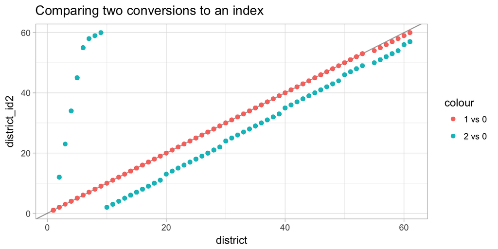

```r
gf_abline(intercept = 0, slope = 1, alpha = 0.4) %>%
gf_point(district_id2 ~ district + color::"2 vs 0", data = Bangladesh) %>%
  gf_point(district_id1 ~ district + color::"1 vs 0", data = Bangladesh) %>%
  gf_labs(title = "Comparing two conversions to an index")
```